## GLG 803 Homework 2

### 3/26/18

Trying my hand at some pythonian programming instead of doing it in R which is much easier for me.

1) Loading in data

```python
import pandas as pd
import numpy as np
import matplotlib.pyplot as plt
data = pd.read_csv("S:/Users/roushjac/Misc/Class/GLG 803/Spring-2018/Homework/Homework_1/Roush_HW1/gauge_data.csv")
```

2) Show the data's head

```python
data.head()
```

|  | Unnamed: 0 | Scan_Num | Date_Time | Temp_Raw | Temp_Calib | Pres_Raw | Pres_Calib | Pres_Ft | Temp_F |
| --- | --- | --- | --- | --- | --- | --- | --- | --- | --- |
| 0 | 2 | 1.0 | 2011-09-05 13:00:00 | 753.0 | 15.5 | 637.0 | 607.3 | 1.992454 | 892.80 |
| 1 | 3 | 2.0 | 2011-09-05 13:14:59 | 754.0 | 15.5 | 636.0 | 605.9 | 1.987861 | 892.80 |
| 2 | 4 | 3.0 | 2011-09-05 13:30:00 | 755.0 | 15.6 | 636.0 | 605.9 | 1.987861 | 898.56 |
| 3 | 5 | 4.0 | 2011-09-05 13:45:00 | 757.0 | 15.6 | 636.0 | 605.9 | 1.987861 | 898.56 |
| 4 | 6 | 5.0 | 2011-09-05 13:59:59 | 760.0 | 15.7 | 636.0 | 605.9 | 1.987861 | 904.32 |

Looks like we've got an extra column. Let's fix this:

```python
data = data.drop('Unnamed: 0', axis=1)
data.set_index('Scan_Num')
```

| Scan_Num | Date_Time | Temp_Raw | Temp_Calib | Pres_Raw | Pres_Calib | Pres_Ft | Temp_F |
| --- | --- | --- | --- | --- | --- | --- | --- |
| 1.0 | 2011-09-05 13:00:00 | 753.0 | 15.5 | 637.0 | 607.3 | 1.992454 | 892.80 |
| 2.0 | 2011-09-05 13:14:59 | 754.0 | 15.5 | 636.0 | 605.9 | 1.987861 | 892.80 |
| 3.0 | 2011-09-05 13:30:00 | 755.0 | 15.6 | 636.0 | 605.9 | 1.987861 | 898.56 |
| 4.0 | 2011-09-05 13:45:00 | 757.0 | 15.6 | 636.0 | 605.9 | 1.987861 | 898.56 |
| 5.0 | 2011-09-05 13:59:59 | 760.0 | 15.7 | 636.0 | 605.9 | 1.987861 | 904.32 |
| 6.0 | 2011-09-05 14:15:00 | 765.0 | 15.8 | 637.0 | 607.3 | 1.992454 | 910.08 |
| 7.0 | 2011-09-05 14:30:00 | 769.0 | 15.9 | 636.0 | 605.9 | 1.987861 | 915.84 |
| 8.0 | 2011-09-05 14:44:59 | 774.0 | 16.0 | 636.0 | 605.9 | 1.987861 | 921.60 |
| 9.0 | 2011-09-05 15:00:00 | 779.0 | 16.1 | 637.0 | 607.3 | 1.992454 | 927.36 |
| 10.0 | 2011-09-05 15:15:00 | 786.0 | 16.2 | 636.0 | 605.9 | 1.987861 | 933.12 |
| 11.0 | 2011-09-05 15:29:59 | 791.0 | 16.3 | 637.0 | 607.3 | 1.992454 | 938.88 |
| 12.0 | 2011-09-05 15:45:00 | 794.0 | 16.4 | 637.0 | 607.3 | 1.992454 | 944.64 |
| 13.0 | 2011-09-05 16:00:00 | 797.0 | 16.4 | 636.0 | 605.9 | 1.987861 | 944.64 |
| 14.0 | 2011-09-05 16:14:59 | 798.0 | 16.5 | 636.0 | 605.9 | 1.987861 | 950.40 |
| 15.0 | 2011-09-05 16:30:00 | 800.0 | 16.5 | 636.0 | 605.9 | 1.987861 | 950.40 |
| 16.0 | 2011-09-05 16:45:00 | 801.0 | 16.5 | 636.0 | 605.9 | 1.987861 | 950.40 |
| 17.0 | 2011-09-05 16:59:59 | 802.0 | 16.6 | 636.0 | 605.9 | 1.987861 | 956.16 |
| 18.0 | 2011-09-05 17:15:00 | 804.0 | 16.6 | 636.0 | 605.9 | 1.987861 | 956.16 |
| 19.0 | 2011-09-05 17:30:00 | 804.0 | 16.6 | 637.0 | 607.3 | 1.992454 | 956.16 |
| 20.0 | 2011-09-05 17:44:59 | 804.0 | 16.6 | 636.0 | 605.9 | 1.987861 | 956.16 |
| 21.0 | 2011-09-05 18:00:00 | 804.0 | 16.6 | 636.0 | 605.9 | 1.987861 | 956.16 |
| 22.0 | 2011-09-05 18:15:00 | 804.0 | 16.6 | 636.0 | 605.9 | 1.987861 | 956.16 |
| 23.0 | 2011-09-05 18:29:59 | 803.0 | 16.6 | 636.0 | 605.9 | 1.987861 | 956.16 |
| 24.0 | 2011-09-05 18:45:00 | 802.0 | 16.6 | 636.0 | 605.9 | 1.987861 | 956.16 |
| 25.0 | 2011-09-05 19:00:00 | 799.0 | 16.5 | 635.0 | 604.6 | 1.983596 | 950.40 |
| 26.0 | 2011-09-05 19:14:59 | 796.0 | 16.4 | 635.0 | 604.6 | 1.983596 | 944.64 |
| 27.0 | 2011-09-05 19:30:00 | 793.0 | 16.4 | 634.0 | 603.2 | 1.979003 | 944.64 |
| 28.0 | 2011-09-05 19:45:00 | 790.0 | 16.3 | 634.0 | 603.2 | 1.979003 | 938.88 |
| 29.0 | 2011-09-05 19:59:59 | 785.0 | 16.2 | 634.0 | 603.2 | 1.979003 | 933.12 |
| 30.0 | 2011-09-05 20:15:00 | 781.0 | 16.1 | 635.0 | 604.6 | 1.983596 | 927.36 |
| ... | ... | ... | ... | ... | ... | ... | ... |
| 5445.0 | 2016-12-02 03:00:00 | 288.0 | 5.1 | 646.0 | 620.1 | 2.034449 | 293.76 |
| 5446.0 | 2016-12-02 03:29:59 | 285.0 | 5.0 | 646.0 | 620.1 | 2.034449 | 288.00 |
| 5447.0 | 2016-12-02 04:00:00 | 283.0 | 5.0 | 647.0 | 621.5 | 2.039042 | 288.00 |
| 5448.0 | 2016-12-02 04:30:00 | 281.0 | 4.9 | 647.0 | 621.5 | 2.039042 | 282.24 |
| 5449.0 | 2016-12-02 04:59:59 | 280.0 | 4.9 | 646.0 | 620.1 | 2.034449 | 282.24 |
| 5450.0 | 2016-12-02 05:30:00 | 279.0 | 4.9 | 646.0 | 620.1 | 2.034449 | 282.24 |
| 5451.0 | 2016-12-02 06:00:00 | 278.0 | 4.8 | 646.0 | 620.1 | 2.034449 | 276.48 |
| 5452.0 | 2016-12-02 06:29:59 | 276.0 | 4.8 | 646.0 | 620.1 | 2.034449 | 276.48 |
| 5453.0 | 2016-12-02 07:00:00 | 275.0 | 4.8 | 646.0 | 620.1 | 2.034449 | 276.48 |
| 5454.0 | 2016-12-02 07:30:00 | 274.0 | 4.8 | 646.0 | 620.1 | 2.034449 | 276.48 |
| 5455.0 | 2016-12-02 07:59:59 | 271.0 | 4.7 | 647.0 | 621.5 | 2.039042 | 270.72 |
| 5456.0 | 2016-12-02 08:30:00 | 270.0 | 4.7 | 645.0 | 618.7 | 2.029856 | 270.72 |
| 5457.0 | 2016-12-02 09:00:00 | 269.0 | 4.6 | 645.0 | 618.7 | 2.029856 | 264.96 |
| 5458.0 | 2016-12-02 09:29:59 | 267.0 | 4.6 | 646.0 | 620.1 | 2.034449 | 264.96 |
| 5459.0 | 2016-12-02 10:00:00 | 265.0 | 4.6 | 646.0 | 620.1 | 2.034449 | 264.96 |
| 5460.0 | 2016-12-02 10:30:00 | 265.0 | 4.6 | 645.0 | 618.7 | 2.029856 | 264.96 |
| 5461.0 | 2016-12-02 10:59:59 | 263.0 | 4.5 | 645.0 | 618.7 | 2.029856 | 259.20 |
| 5462.0 | 2016-12-02 11:30:00 | 264.0 | 4.5 | 645.0 | 618.7 | 2.029856 | 259.20 |
| 5463.0 | 2016-12-02 12:00:00 | 263.0 | 4.5 | 646.0 | 620.1 | 2.034449 | 259.20 |
| 5464.0 | 2016-12-02 12:29:59 | 263.0 | 4.5 | 645.0 | 618.7 | 2.029856 | 259.20 |
| 5465.0 | 2016-12-02 13:00:00 | 265.0 | 4.6 | 645.0 | 618.7 | 2.029856 | 264.96 |
| 5466.0 | 2016-12-02 13:30:00 | 266.0 | 4.6 | 645.0 | 618.7 | 2.029856 | 264.96 |
| 5467.0 | 2016-12-02 13:59:59 | 268.0 | 4.6 | 646.0 | 620.1 | 2.034449 | 264.96 |
| 5468.0 | 2016-12-02 14:30:00 | 271.0 | 4.7 | 645.0 | 618.7 | 2.029856 | 270.72 |
| 5469.0 | 2016-12-02 15:00:00 | 273.0 | 4.7 | 646.0 | 620.1 | 2.034449 | 270.72 |
| 5470.0 | 2016-12-02 15:29:59 | 275.0 | 4.8 | 644.0 | 617.4 | 2.025591 | 276.48 |
| 5471.0 | 2016-12-02 16:00:00 | 277.0 | 4.8 | 644.0 | 617.4 | 2.025591 | 276.48 |
| 5472.0 | 2016-12-02 16:30:00 | 278.0 | 4.8 | 645.0 | 618.7 | 2.029856 | 276.48 |
| 5473.0 | 2016-12-02 16:59:59 | 279.0 | 4.9 | 645.0 | 618.7 | 2.029856 | 282.24 |
| 5474.0 | 2016-12-02 17:30:00 | 281.0 | 4.9 | 645.0 | 618.7 | 2.029856 | 282.24 |

91436 rows × 7 columns

3) Creating a boxplot of temperature and pressure fields

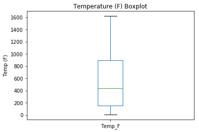

```python
# Temp boxplot
tempFig = data.boxplot(column='Temp_F', grid=False)
tempFig.set_title('Temperature (F) Boxplot')
tempFig.set_ylabel('Temp (F)')
tempFig.xaxis.label.set_visible(False) # X axis is useless here - not working though
```

This data looks to have the correct distribution (compared to Bailey's), but the numbers are obviously wrong - not sure where that happened since my numbers were right for HW1...

At least there are no outliers!

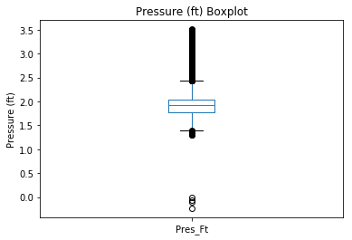

```python
# Pressure boxplot
tempFig = data.boxplot(column='Pres_Ft', grid=False)
tempFig.set_title('Pressure (ft) Boxplot')
tempFig.set_ylabel('Pressure (ft)')
tempFig.xaxis.label.set_visible(False) # X axis is useless here - not working though
```

Looks like pressure has got some outliers on the high side.

The outliers around 0 ft are most likely instrument failure.

4) Creating histograms of same data

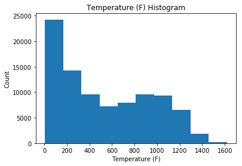

```python
# Temp histogram
tempHist = data.hist(column='Temp_F', grid=False)
plt.title('Temperature (F) Histogram')
plt.ylabel('Count')
plt.xlabel('Temperature (F)')
```

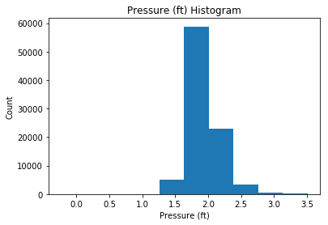

```python
# Pressure histogram
tempHist = data.hist(column='Pres_Ft', grid=False)
plt.title('Pressure (ft) Histogram')
plt.ylabel('Count')
plt.xlabel('Pressure (ft)')
```

Pressure looks to be much closer to a normal distribution.

5) Plotting time series of temp and pressure fields

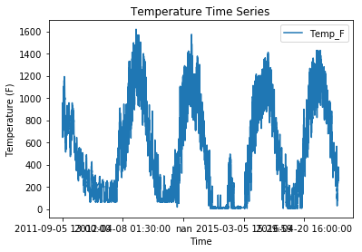

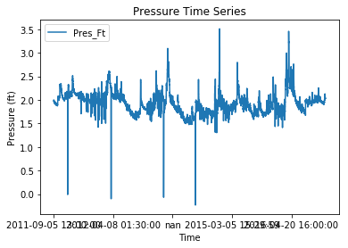

```python
tempTS = data.plot(x='Date_Time', y='Temp_F')
plt.title('Temperature Time Series')
plt.ylabel('Temperature (F)')
plt.xlabel('Time')

tempTS = data.plot(x='Date_Time', y='Pres_Ft')
plt.title('Pressure Time Series')
plt.ylabel('Pressure (ft)')
plt.xlabel('Time')
```

The cycles in this data are likely seasonal changes.

6) Making scatter plot of pressure vs temp

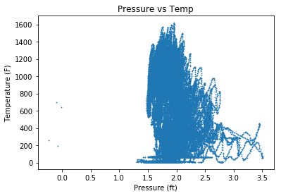

```python
scatter = data.plot.scatter(x='Pres_Ft', y='Temp_F', s=0.5)
plt.title('Pressure vs Temp')
plt.ylabel('Temperature (F)')
plt.xlabel('Pressure (ft)')
```

This scatter plot is u-g-l-y.